# OpenGWASDB at full scale — OGS-00016

The FinnGen R13 public summary statistics in one Dense Store Release · 58.5 billion associations · validated against the source files

Published

September 30, 2026

**ImportantWhat this measures**

Every public FinnGen R13 endpoint — **2,754 Analyses, 21,230,615 variants, 58.5 billion associations** — built into a single Dense Store Release, then checked two ways: **against the 2,754 source files it was built from**, and against **what is already known about human genetics**. The same query shapes and memory probe as the OGS-00009 report are measured for comparison.

- **126.6 GB** on disk against **2.16 TB** of source `.gz` across 2,754 files — a **17.1x** reduction, **2.16 bytes per association**.
- **275 million cells** from 13 sampled Analyses compared against their source rows: z is within 4.89e-04 of `beta / sebeta`, standard error within 0.84%, allele frequency within 0.20%. **Every gate passes.**
- An indexed top-hits query returns in **2.46 ms**; a PheWAS across all 2,754 endpoints in **6.70 ms**.
- Built in **12.35 h**, plus 1.92 h for the top-hit index.

One property of the FinnGen source is *not* preserved and is documented under Findings: about 0.9% of source rows share a variant identity with another row and end up in one cell.

## Scope

| Property | Value |
| --- | --- |
| Store Release | OGS-00016 (`finngen-r13-full`) |
| Completion state | observed-only |
| Analyses | 2,754 (222 of them `_WIDE` endpoint definitions) |
| Stored effect scale | 2,751 `log_or`, 3 `sd` |
| Cases per binary endpoint | 50 – 434,037 (median 1,031) |
| Genome-wide hits per Analysis | median 1, max 223,307, 1,133 with none |
| Variants | 21,230,615 |
| Associations | 58,469,113,710 |
| Reference assembly | GRCh38 |
| Encoding | z `int16_fixed`, se `int8_residual`, eaf `int8_residual` (format 0.1.0, encoding v3) |
| Built by opengwasdb | `99bd904` |
| Measured at | 2026-09-30T15:52:49.806577+00:00 (`3745a3b`) |

Timings are the median of 5 repetitions after a warm-up call, under a warm operating-system cache. Memory is measured separately — see Memory footprint.

# Validation

`opengwasdb validate` passed on this release — but it checks the store’s internal consistency and never opens a source file. Everything below does.

## Source fidelity

Each sampled Analysis’s whole source file is parsed and every row matched to the store’s variant axis by an independent allele-pair matcher (not the builder’s). The store’s cells are then decoded through the public query API and compared with `beta / sebeta`, `sebeta` and `af_alt`, after negating the source’s ALT-oriented effect where the store’s canonical effect allele is the source REF. Before anything is compared, each source file’s SHA-256 is checked against the build manifest’s, so the files read here are the files that were built from.

| Gate | Bound | Where it comes from |
| --- | --- | --- |
| z | abs error ≤ 4.89e-04 | half a step of the int16 fixed-point code (scale 1,024); |
| se | relative error ≤ 1% | ADR 0037’s ordinary-cell bound for the int8 residual code |
| eaf | relative error ≤ 0.207% | half a logit step at the store’s chosen range, plus float32 rounding |
| missingness | exact | an unusable source row has no cell; a usable one has one, unless it collapses (below) |

| Analysis | Cells compared | max abs z err | max rel se err | max rel eaf err | Sign disagreements |  | z |
| --- | --- | --- | --- | --- | --- | --- | --- |
| `BMI_IRN` | 21,132,070 | 4.89e-04 | 0.84% | 0.199% | 0 | 99 / 99 | pass |
| `HEIGHT_IRN` | 21,132,128 | 4.89e-04 | 0.84% | 0.199% | 0 | 1 / 1 | pass |
| `T2D` | 21,134,043 | 4.89e-04 | 0.84% | 0.199% | 0 | 8 / 8 | pass |
| `T2D_WIDE` | 21,133,603 | 4.89e-04 | 0.84% | 0.199% | 0 | 0 / 0 | pass |
| `I9_CHD` | 21,134,187 | 4.89e-04 | 0.84% | 0.198% | 0 | 0 / 0 | pass |
| `G6_ALZHEIMER` | 21,134,187 | 4.88e-04 | 0.84% | 0.198% | 0 | 47 / 47 | pass |
| `AB1_ANUG_WIDE` | 21,134,147 | 4.88e-04 | 0.84% | 0.198% | 0 | 0 / 0 | pass |
| `AB1_SCABIES_WIDE` | 21,134,184 | 4.88e-04 | 0.84% | 0.198% | 0 | 0 / 0 | pass |
| `E4_FLUIDELECTRONAS` | 21,132,849 | 4.88e-04 | 0.84% | 0.199% | 0 | 0 / 0 | pass |
| `E4_THYMUSDIS` | 21,133,924 | 4.88e-04 | 0.84% | 0.199% | 0 | 0 / 0 | pass |
| `I9_AORTANEUR` | 21,133,809 | 4.88e-04 | 0.84% | 0.199% | 0 | 0 / 0 | pass |
| `KRA_PSY_DEMENTIA_EXMORE` | 21,132,077 | 4.88e-04 | 0.84% | 0.199% | 0 | 40 / 40 | pass |
| `O15_ABORT_OTHER` | 21,121,584 | 4.88e-04 | 0.84% | 0.199% | 0 | 0 / 0 | pass |

Across the 13 Analyses — a quantitative pair (`BMI_IRN`, `HEIGHT_IRN`), the flagship endpoints, an endpoint and its `_WIDE` twin, the endpoint with the fewest cases, and 6 drawn at random (seed 0) — that is **274,722,792 cells** from 277,229,528 source rows.

- **Orientation.** 49.5% of cells are stored on the opposite allele to the source’s ALT, and none of them disagree in sign (0 sign disagreements across all 13).
- **Precision.** The largest z error is 4.89e-04 against a bound of 4.89e-04: the store is as accurate as its code allows and no more wrong than that. The 195 cells with |z| ≥ 32 lie outside the fixed-point range and round-trip exactly through the exception table.
- **P-values.** `-log10 p` recomputed from the stored z agrees with the source `pval` to within 0.0076 (for p < 0.01).
- **Missingness.** 0 source rows were unusable (non-finite effect or non-positive SE) and 0 of them have a store cell; 0 usable rows are missing from the store outside the collapsed pairs below; and 0 store cells lack a source row. Every source row matched a store variant (0 did not).
- **Statuses.** Every cell is `observed`; this is an observed-only release.
- **Allele frequency near 1.** A relative bound on `1 - eaf` is unresolvable in `float32` once EAF is within 0.2% of 1, so on 19.6% of cells only the EAF side is checked.

## Known loci

A store can reproduce its source perfectly and still be wrong if the source were mis-oriented on the way in. So the lead variants of well-established associations are looked up and their effect expressed on the **published risk allele** — independent of how the store chose its canonical allele.

| Locus | Variant | Endpoint | Risk allele | Risk-allele freq. | z (risk allele) | Effect (log-OR or SD) | -log10 p | Result |
| --- | --- | --- | --- | --- | --- | --- | --- | --- |
| TCF7L2 | rs7903146 | `T2D` | T | 0.199 | +36.0 | +0.248 | 284 | pass |
| PPARG | rs1801282 | `T2D` | C | 0.830 | +12.4 | +0.094 | 35 | pass |
| FTO | rs9939609 | `BMI_IRN` | A | 0.403 | +37.8 | +0.085 | 312 | pass |
| MC4R | rs17782313 | `BMI_IRN` | C | 0.185 | +19.0 | +0.054 | 80 | pass |
| APOE | rs429358 | `G6_ALZHEIMER` | C | 0.181 | +73.1 | +0.994 | 1162 | pass |
| TOMM40 | rs2075650 | `G6_ALZHEIMER` | G | 0.173 | +45.1 | +0.656 | 443 | pass |
| CDKN2B-AS1 | rs1333049 | `I9_CHD` | C | 0.419 | +23.1 | +0.134 | 117 | pass |
| CDKN2B-AS1 | rs4977574 | `I9_CHD` | G | 0.432 | +22.8 | +0.131 | 114 | pass |

## PheWAS of two pleiotropic variants

One variant, looked up across all 2,754 endpoints. If the store’s variant and Analysis axes were misaligned, the strongest endpoints would not make sense.

**TCF7L2 — rs7903146** (`10:112998590:C:T`): 11 of 2,754 endpoints reach |z| > 5.45.

| Endpoint | Label |  |
| --- | --- | --- |
| `KELA_DIAB_INSUL_EXMORE` | Diabetes, insulin treatment (Kela reimbursement) (more control exclusions) | 36.2 |
| `T2D` | Type 2 diabetes, definitions combined | 36.0 |
| `T2D_WIDE` | Type 2 diabetes, wide definition | 31.4 |
| `GEST_DIABETES` | Gestational diabetes (for exclusion) | 11.5 |
| `RX_STATIN` | Statin medication | 10.0 |
| `WEIGHT_IRN` | Weight, inverse-rank normalized | 7.6 |
| `BMI_IRN` | Body mass index, inverse-rank normalized | 7.1 |
| `O15_PREG_OTHER_MAT_DISORD` | Other maternal disorders predominantly related to pregnancy | 6.7 |

**APOE — rs429358** (`19:44908684:C:T`): 94 of 2,754 endpoints reach |z| > 5.45.

| Endpoint | Label |  |
| --- | --- | --- |
| `G6_NEURODEGENERATIVE` | Unspecific neurodegenerative disorder | 82.4 |
| `F5_DEMENTIA` | Dementia | 79.9 |
| `F5_DEMENTIA_INCLAVO` | Dementia, including avohilmo | 79.5 |
| `G6_ALZHEIMER` | Alzheimer disease | 73.1 |
| `KRA_PSY_DEMENTIA_EXMORE` | Any dementia (more control exclusions) | 71.3 |
| `G6_AD_STRICT` | Alzheimer’s disease, strict definition | 69.8 |
| `AD_LO_EXMORE` | Alzheimer’s disease (Late onset) (more control exclusions) | 64.0 |
| `F5_ALZHDEMENT` | Dementia in Alzheimer disease | 59.5 |

## Mendelian randomisation

Three IVW pairs run end to end through the store: top hits → distance clumping → lookup of exposure and outcome at the same variants → estimate. Because the store orients every Analysis to one effect allele, no harmonisation step is needed; if orientation were wrong for even a fraction of variants the estimates below would be pulled towards the null.

| Exposure → outcome | Instruments | Median F | Sign-concordant | IVW beta | IVW se | p | Cochran Q / df |
| --- | --- | --- | --- | --- | --- | --- | --- |
| `BMI_IRN` → `T2D` | 589 (of 55,460 hits) | 39 | 92% | **0.930** | 0.041 | 4.6e-112 | 4625 / 588 |
| `BMI_IRN` → `I9_CHD` | 589 (of 55,460 hits) | 39 | 66% | **0.231** | 0.023 | 1.2e-24 | 1319 / 588 |
| `T2D` → `I9_CHD` | 312 (of 25,771 hits) | 41 | 76% | **0.147** | 0.012 | 1.8e-34 | 856 / 311 |

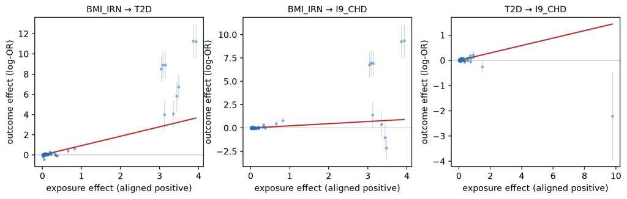

All three estimates are positive and nominally significant, as the literature expects for each pair. Each instrument is one point; the red line is the IVW slope through the origin.

**WarningA pipeline check, not a causal result**

Exposure and outcome are drawn from **the same cohort**, so sample overlap biases every estimate towards the observational association, and `BMI_IRN` is measured in a subset of FinnGen. Instruments are distance-clumped at 1,000 kb, not LD-clumped. Q well above its degrees of freedom is expected and is absorbed by scaling the standard error by √(Q/df). What this establishes is that instruments are found, effect signs survive orientation, and standard errors propagate — the same purpose the MR serves in the OGS-00009 report.

# Findings

## Insertion and deletion rows that share one identity are stored in one cell

In every sampled Analysis, **96,413 pairs of source rows** — 0.90% of the file — resolve to the same store cell. Each pair is an insertion and a deletion at one site. For example, chr1:827,587 carries both `G>GGGGCC` and `GGGGCC>G` in the source, with different effects. They are different variants, but the store identifies a variant by its site plus the *unordered* allele pair (the alphabetically first allele is the effect allele), so both map to one ALID.

- Across all 13 Analyses the store’s cell carries the **later** source row in 1,252,949 of 1,253,368 pairs. In the other 419 the two rows agree to within the store’s precision, so which was kept cannot be told. The earlier row alone is kept in 0 pairs and neither is kept in 0.
- The loss is structural: nearly the same pairs collapse in every Analysis, so the variant axis has one entry where FinnGen has two.
- It is silent. A lookup by that ALID returns the later row’s statistics whichever of the two variants was meant, and `opengwasdb validate` passes because the axis is internally consistent.
- It affects indels only: 0 of the collapsed rows are SNVs.

This is a property of the store’s variant identity (`orient_to_canonical` in `opengwasdb/variants/normalise.py`), surfaced here rather than introduced by this build. The other 99.1% of source rows are stored one-to-one.

# Storage

| Measure | Value |
| --- | --- |
| Store Release | 126.57 GB |
| Source `.gz` | 2,160.7 GB across 2,754 files |
| Compression ratio | **17.1x** |
| Bytes per association | 2.165 B |

The sources are already gzip-compressed text, so this is a reduction against compressed input. It comes from storing z and standard error as fixed-point and residual codes rather than text floats, and from sharing one variant axis across all 2,754 Analyses rather than repeating position, alleles, rsID and gene name in every file.

| Component | Size | Share |
| --- | --- | --- |
| `data.zarr/z` | 84.43 GB | 66.7% |
| `data.zarr/se` | 23.65 GB | 18.7% |
| `data.zarr/eaf` | 15.48 GB | 12.2% |
| `data.zarr/top_hits` | 1.03 GB | 0.8% |
| `variant_alid_bytes.npy` | 0.68 GB | 0.5% |
| `variant_rsid_bytes.npy` | 0.49 GB | 0.4% |
| `variants.tsv.gz` | 0.36 GB | 0.3% |
| `variant_offsets.npy` | 0.17 GB | 0.1% |

# Build

| Step | Wall clock |
| --- | --- |
| Build (`build-dense-vcf`) | 12.35 h (44,448 s) |
| Top-hit index | 1.92 h (6,906 s) |
| Overview page | 0.00 h (2 s) |
| `opengwasdb validate` | 3.54 h (12,733 s) |

The build ran 32 workers, for **1.32 million associations/s** — from 2.16 TB of source text.

# Query performance

| Query | Median | p95 | Results |
| --- | --- | --- | --- |
| Top hits for one Analysis (p < 5e-8) | **2.46 ms** | 2.51 ms | 25,771 |
| PheWAS: one variant, all Analyses | **6.70 ms** | 8.20 ms | 2,754 |
| Region restricted to one Analysis | **39.51 ms** | 73.73 ms | 6,602 |
| Random lookup: 10 variants x 100 Analyses | **72.76 ms** | 75.59 ms | 1,000 |
| Random lookup: 100 variants x 10 Analyses | **616.93 ms** | 656.11 ms | 1,000 |
| Region across all Analyses | **4.31 s** | 4.38 s | 18,180,899 |
| One Analysis, genome-wide | **60.55 s** | 64.76 s | 21,230,471 |

The endpoint is `T2D`; the region is chr10:112.5–113.5 Mb around *TCF7L2*; the PheWAS variant is rs7903146.

**Bulk against the source.** Reading one whole Analysis is the shape the source files are laid out for, and it is where the store does *worst*. Parsing `finngen_R13_T2D.gz` (811 MB) into z, se and allele frequency took **20.1 s** (median of 3); the store’s genome-wide read of the same Analysis takes **60.55 s**, which is 3.0x slower. The reason is the chunk shape: each chunk spans 1,000 Analyses, so reading one column decompresses about 1,000x the values it returns. That is the price of the cheap PheWAS and region reads above, and it is a trade the format makes deliberately; a consumer that mostly reads whole Analyses should keep the source files or use a different layout.

# Memory footprint

Each query shape runs in a fresh interpreter. `Baseline` is resident memory with the store open but before the query runs; `Peak` is sampled on a background thread *during* the query.

| Query | Baseline | Peak | Query cost | Results |
| --- | --- | --- | --- | --- |
| Top hits for one Analysis (p < 5e-8) | 304.6 MB | 305.8 MB | **1.2 MB** | 25,771 |
| PheWAS: one variant, all Analyses | 305.3 MB | 322.8 MB | **17.5 MB** | 2,754 |
| Region restricted to one Analysis | 305.2 MB | 328.1 MB | **23.0 MB** | 6,602 |
| Random lookup: 10 variants x 100 Analyses | 304.7 MB | 348.5 MB | **43.8 MB** | 1,000 |
| Random lookup: 100 variants x 10 Analyses | 304.7 MB | 762.9 MB | **458.2 MB** | 1,000 |
| Region across all Analyses | 304.6 MB | 2.33 GB | **2.03 GB** | 18,180,899 |
| One Analysis, genome-wide | 304.9 MB | 22.24 GB | **21.95 GB** | 21,230,471 |

# Limitations

- **Observed-only.** Missing associations are absent, not imputed.
- **Sampled fidelity.** The cell-by-cell comparison covers 13 of 2,754 Analyses. The build manifest records a SHA-256 for every source file; only the sampled files were re-hashed for this report. The sample is named anchors plus a seeded random draw, so it can be regenerated.
- **Single ancestry.** FinnGen is a Finnish cohort; allele frequencies and LD are population-specific.
- **Warm cache, one machine.** Timings follow a warm-up call on one host.
- **The MR is a smoke test**, for the reasons above.